# exploratory_data_analysis_exercise

## Exercise:

```
Download Haberman Cancer Survival dataset from Kaggle. You may have to create a Kaggle account to donwload data. (https://www.kaggle.com/gilsousa/habermans-survival-data-set)
Perform a similar alanlaysis as above on this dataset with the following sections:

High level statistics of the dataset: number of points, numer of features, number of classes, data-points per class.
Explain our objective.
Perform Univaraite analysis(PDF, CDF, Boxplot, Voilin plots) to understand which features are useful towards classification.
Perform Bi-variate analysis (scatter plots, pair-plots) to see if combinations of features are useful in classfication.
Write your observations in english as crisply and unambigously as possible. Always quantify your results.
```

```python
import pandas as pd
import seaborn as sns
import matplotlib.pyplot as plt
import numpy as np

#Load Haberman Cancer Survival dataset
hcs = pd.read_csv("/content/drive/MyDrive/Colab Notebooks/Assignment 2/haberman.csv")
```

```python
#How Many data-points and features
print(hcs.shape)
```

```
(306, 4)
```

we have 306 rows and 4 columns

```python
#number of classes
print(hcs.columns)
```

```
Index(['age', 'year', 'nodes', 'status'], dtype='object')
```

```python
hcs.head()
```

|  | age | year | nodes | status |
| --- | --- | --- | --- | --- |
| 0 | 30 | 64 | 1 | 1 |
| 1 | 30 | 62 | 3 | 1 |
| 2 | 30 | 65 | 0 | 1 |
| 3 | 31 | 59 | 2 | 1 |
| 4 | 31 | 65 | 4 | 1 |

```python
hcs.tail()
```

|  | age | year | nodes | status |
| --- | --- | --- | --- | --- |
| 301 | 75 | 62 | 1 | 1 |
| 302 | 76 | 67 | 0 | 1 |
| 303 | 77 | 65 | 3 | 1 |
| 304 | 78 | 65 | 1 | 2 |
| 305 | 83 | 58 | 2 | 2 |

```python
#data-points per class
hcs['year'].value_counts()
```

```
58    36
64    31
63    30
66    28
65    28
60    28
59    27
61    26
67    25
62    23
68    13
69    11
Name: year, dtype: int64
```

```python
hcs['age'].value_counts()
```

```
52    14
54    13
50    12
47    11
53    11
43    11
57    11
55    10
65    10
49    10
38    10
41    10
61     9
45     9
42     9
```

[output cut: 35 more lines]

```python
hcs['nodes'].value_counts()
```

```
0     136
1      41
2      20
3      20
4      13
6       7
7       7
8       7
5       6
9       6
13      5
14      4
11      4
10      3
15      3
```

[output cut: 17 more lines]

```python
hcs['status'].value_counts()
```

```
1    225
2     81
Name: status, dtype: int64
```

Analysis of survival of patients who had undergone surgery 225 patients survived more than 5 years and 81 patients survived less than 5 years

# Bi-variate analysis

## **2-D Scatter Plot**

```python
print(hcs.columns)
```

```
Index(['age', 'year', 'nodes', 'status'], dtype='object')
```

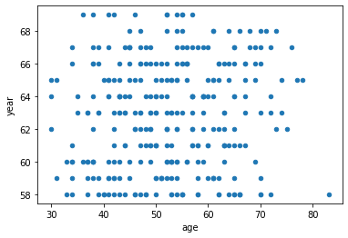

```python
hcs.plot(kind="scatter", x='age', y='year')
```

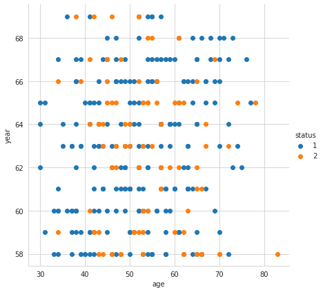

```python
#2-D scatter plot with color code of survival list
sns.set_style("whitegrid");
sns.FacetGrid(hcs, hue="status", size=6).map(plt.scatter,"age","year").add_legend();
plt.show()
```

## Pair-plot

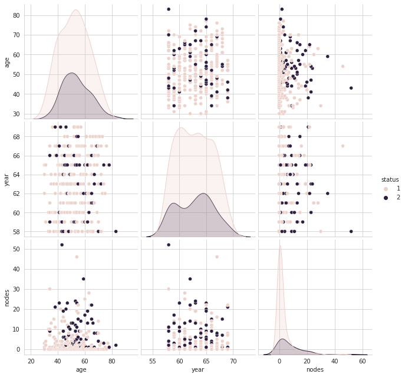

```python
plt.close();
sns.set_style("whitegrid");
sns.pairplot(hcs, hue="status", size=3).add_legend;
plt.show()
```

### Observations:

Survival status is random spread but based on analysis

- There is high survival between age group 30 to 40
- pateient have nodes between 0 and 1 has high survival and patients having node range 25 has very less survival

# Univaraite analysis

### PDF

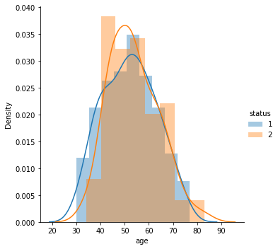

```python
hcs_surv=hcs.loc[hcs["status"] == 1];
hcs_canc=hcs.loc[hcs["status"] == 2];

sns.FacetGrid(hcs, hue='status',height=5).map(sns.distplot,'age').add_legend();
plt.show()
```

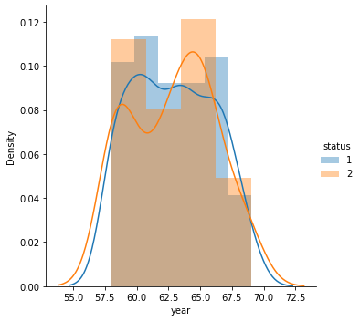

```python
sns.FacetGrid(hcs, hue='status',height=5).map(sns.distplot,'year').add_legend();
plt.show()
```

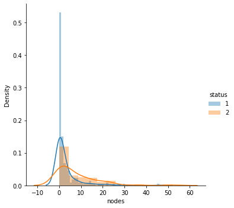

```python
sns.FacetGrid(hcs, hue='status',height=5).map(sns.distplot,'nodes').add_legend();
plt.show()
```

```
[0.03703704 0.12345679 0.19753086 0.19753086 0.13580247 0.12345679
 0.09876543 0.04938272 0.02469136 0.01234568]
[34.  38.9 43.8 48.7 53.6 58.5 63.4 68.3 73.2 78.1 83. ]
```

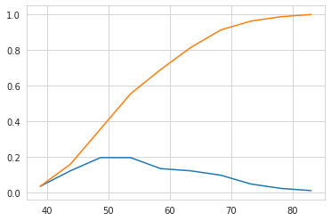

```python
counts, bin_edges = np.histogram(hcs_canc['age'], bins=10, density= True);

pdf = counts/(sum(counts));
print(pdf);
print(bin_edges);
cdf=np.cumsum(pdf);

plt.plot(bin_edges[1:],pdf)
plt.plot(bin_edges[1:], cdf)
```

```
[0.56790123 0.14814815 0.13580247 0.04938272 0.07407407 0.
 0.01234568 0.         0.         0.01234568]
[ 0.   5.2 10.4 15.6 20.8 26.  31.2 36.4 41.6 46.8 52. ]
[0.83555556 0.08       0.02222222 0.02666667 0.01777778 0.00444444
 0.00888889 0.         0.         0.00444444]
[ 0.   4.6  9.2 13.8 18.4 23.  27.6 32.2 36.8 41.4 46. ]
```

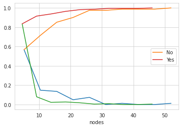

```python
#cancer
counts1, bin_edges1 = np.histogram(hcs_canc['nodes'], bins=10, density= True);

pdf1 = counts1/(sum(counts1));
print(pdf1);
print(bin_edges1);
cdf1=np.cumsum(pdf1);

sns.set_style("whitegrid");
plt.plot(bin_edges1[1:],pdf1);
plt.plot(bin_edges1[1:], cdf1, label = 'No');
plt.xlabel('nodes')

#survival
counts2, bin_edges2 = np.histogram(hcs_surv['nodes'], bins=10, density= True);

pdf2 = counts2/(sum(counts2));
print(pdf2);
print(bin_edges2);
cdf2=np.cumsum(pdf2);

plt.plot(bin_edges2[1:],pdf2);
plt.plot(bin_edges2[1:], cdf2, label='Yes');
plt.xlabel('nodes');

plt.legend();
plt.show();
```

## Voilin Plot

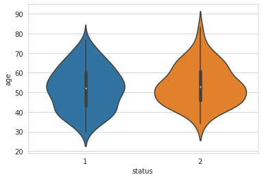

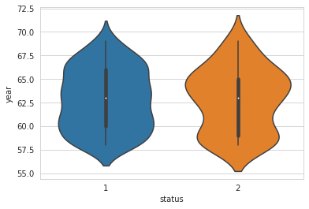

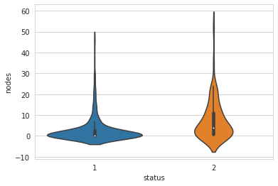

```python
sns.violinplot(x="status", y="age", data=hcs, size=8)
plt.show()
sns.violinplot(x="status", y="year", data=hcs, size=8)
plt.show()
sns.violinplot(x="status", y="nodes", data=hcs, size=8)
plt.show()
```

## BOX PLOT

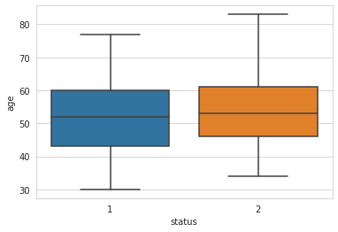

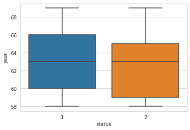

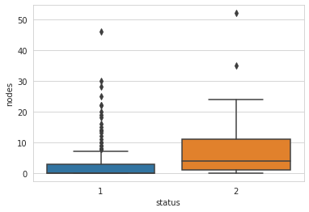

```python
sns.boxplot(x="status", y="age", data=hcs)
plt.show()
sns.boxplot(x="status", y="year", data=hcs)
plt.show()
sns.boxplot(x="status", y="nodes", data=hcs)
plt.show()
```

### Post univariate and bivariate analysis

- There is high survival between/less age group 30 to 40
- patient having nodes between 0 and 1 has high survival and patients having node range >=25 has very less survival
- Between 1960 and 1965 there were more unsuccessful operations.

### Conclusion

- These aren't the deciding factors but however there were non-survival cases between age group 30 to 40 but people less than 35 years have more chance of survival
- The objective of classifying the survival status of a new patient based on the given features is a difficult task as the data is imbalanced.